# Colaboración INMEGEN

## Pretratamiento

Para considerar solamente las lecturas de alta calidad antes de realizar la asignación funcional y taxonómica se realizó un pretratamiento a cada una de las muestras. En la siguiente figura se puede observar los pasos que se incluyeron en esta parte del análisis, donde se incluye el filtrado de calidad de las lecturas, la remoción de rRNA y las lecturas pertenecientes al hospedero (humano) que no se necesitan para los análisis siguientes.

[interactive chart not shown]

1. Filtrado de calidad con *Trimmomatic* (remoción de adaptadores y calidad promedio de la lectura >Q20)
2. Remoción de ribosomales con *ribopicker*
3. Remoción de lecturas del hospedero con *knead2*

[output not shown]

**IMPORTANTE: Se retiraron de los análisis posteriores las siguientes muestras RL619, RL621 y RL625 por su bajo número de lecturas después del pretratamiento.**

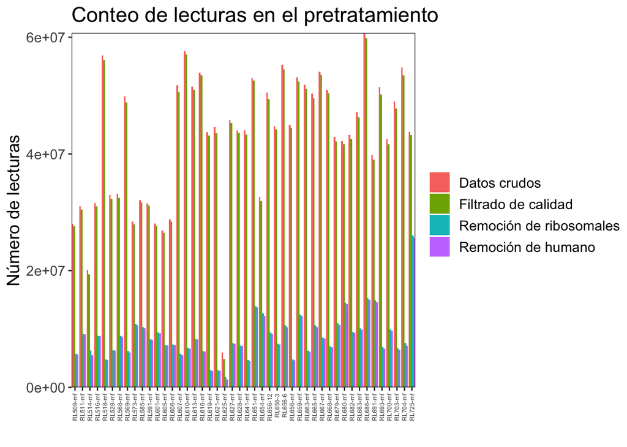

| Muestra | Después de filtros de calidad | Sin ribosomales | Sin humano |
| --- | --- | --- | --- |
| Promedio todas las muestras | 98.35% | 20.39% | 19.89% |

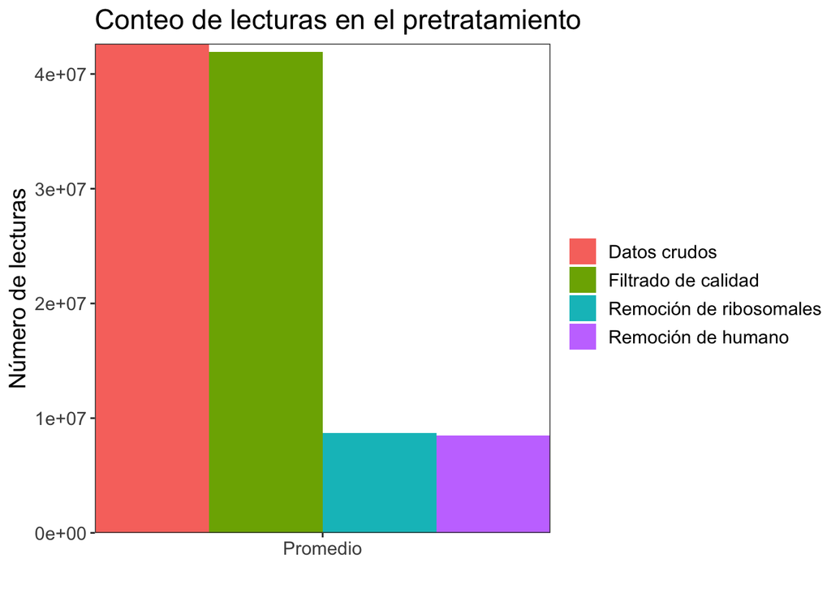

## Pipeline para análisis de metatranscriptoma

En la siguiente figura se encuentra una descripción gráfica de los análisis que se realizaron para conocer la clasificación taxonómica y funcional de los metatranscriptomas de cada una de las muestras para poder hacer las comparaciones entre los grupos. En breve, se utilizó MetaPhlAn para la asignación taxonómica, diversidad alfa, diversidad y beta y LefSe para conocer la especies expresadas diferencialmente entre grupos. Para conocer la funcionalidad de cada muestra, se utilizó HUMAnN3 que nos permitió obtener los genes, rutas metabólicas y la expresión diferencial de las mismas entre los grupos control y NASH

[interactive chart not shown]